# microRNAs and Primary Familial Brain Calcification

## Denis Arthur Pinheiro de Moura¹

### 1 - Laboratório de Imunopatologia Keizo Asami, Universidade Federal de Pernambuco

#### Methods

```python
import pandas as pd
import numpy as np
```

```python
slc20a2 = pd.read_html('miRDBslc20a2.html')[0]
```

```python
slc20a2.columns = slc20a2.iloc[0]
```

```python
slc20a2 = slc20a2[1:]
```

```python
slc20a2.head()
```

|  | Target Detail | Target Rank | Target Score | miRNA Name | Gene Symbol | Gene Description |
| --- | --- | --- | --- | --- | --- | --- |
| 1 | Details | 1 | 99 | hsa-miR-144-3p | SLC20A2 | solute carrier family 20 member 2 |
| 2 | Details | 2 | 99 | hsa-miR-3613-3p | SLC20A2 | solute carrier family 20 member 2 |
| 3 | Details | 3 | 98 | hsa-miR-3924 | SLC20A2 | solute carrier family 20 member 2 |
| 4 | Details | 4 | 97 | hsa-miR-101-3p | SLC20A2 | solute carrier family 20 member 2 |
| 5 | Details | 5 | 97 | hsa-miR-12129 | SLC20A2 | solute carrier family 20 member 2 |

```python
pdgfb = pd.read_html('miRDBpdgfb.html')[0]
pdgfb.columns = pdgfb.iloc[0]
pdgfb = pdgfb[1:]
pdgfb.head()
```

|  | Target Detail | Target Rank | Target Score | miRNA Name | Gene Symbol | Gene Description |
| --- | --- | --- | --- | --- | --- | --- |
| 1 | Details | 1 | 99 | hsa-miR-6867-5p | PDGFB | platelet derived growth factor subunit B |
| 2 | Details | 2 | 95 | hsa-miR-4451 | PDGFB | platelet derived growth factor subunit B |
| 3 | Details | 3 | 94 | hsa-miR-6851-5p | PDGFB | platelet derived growth factor subunit B |
| 4 | Details | 4 | 94 | hsa-miR-3689d | PDGFB | platelet derived growth factor subunit B |
| 5 | Details | 5 | 93 | hsa-miR-3120-3p | PDGFB | platelet derived growth factor subunit B |

```python
pdgfrb = pd.read_html('miRDBpdgfrb.html')[0]
pdgfrb.columns = pdgfrb.iloc[0]
pdgfrb = pdgfrb[1:]
pdgfrb.head()
```

|  | Target Detail | Target Rank | Target Score | miRNA Name | Gene Symbol | Gene Description |
| --- | --- | --- | --- | --- | --- | --- |
| 1 | Details | 1 | 96 | hsa-miR-6764-5p | PDGFRB | platelet derived growth factor receptor beta |
| 2 | Details | 2 | 95 | hsa-miR-4456 | PDGFRB | platelet derived growth factor receptor beta |
| 3 | Details | 3 | 93 | hsa-miR-1915-3p | PDGFRB | platelet derived growth factor receptor beta |
| 4 | Details | 4 | 92 | hsa-miR-9-5p | PDGFRB | platelet derived growth factor receptor beta |
| 5 | Details | 5 | 91 | hsa-miR-6804-5p | PDGFRB | platelet derived growth factor receptor beta |

```python
xpr1 = pd.read_html('miRDBxpr1.html')[0]
xpr1.columns = xpr1.iloc[0]
xpr1 = xpr1[1:]
xpr1.head()
```

|  | Target Detail | Target Rank | Target Score | miRNA Name | Gene Symbol | Gene Description |
| --- | --- | --- | --- | --- | --- | --- |
| 1 | Details | 1 | 99 | hsa-miR-1252-5p | XPR1 | xenotropic and polytropic retrovirus receptor 1 |
| 2 | Details | 2 | 98 | hsa-miR-2054 | XPR1 | xenotropic and polytropic retrovirus receptor 1 |
| 3 | Details | 3 | 97 | hsa-miR-5692a | XPR1 | xenotropic and polytropic retrovirus receptor 1 |
| 4 | Details | 4 | 97 | hsa-miR-548at-5p | XPR1 | xenotropic and polytropic retrovirus receptor 1 |
| 5 | Details | 5 | 96 | hsa-miR-30d-5p | XPR1 | xenotropic and polytropic retrovirus receptor 1 |

```python
jam2 = pd.read_html('miRDBjam2.html')[0]
jam2.columns = jam2.iloc[0]
jam2 = jam2[1:]
jam2.head()
```

|  | Target Detail | Target Rank | Target Score | miRNA Name | Gene Symbol | Gene Description |
| --- | --- | --- | --- | --- | --- | --- |
| 1 | Details | 1 | 95 | hsa-miR-514a-3p | JAM2 | junctional adhesion molecule 2 |
| 2 | Details | 2 | 95 | hsa-miR-514b-3p | JAM2 | junctional adhesion molecule 2 |
| 3 | Details | 3 | 93 | hsa-miR-1205 | JAM2 | junctional adhesion molecule 2 |
| 4 | Details | 4 | 93 | hsa-miR-7114-5p | JAM2 | junctional adhesion molecule 2 |
| 5 | Details | 5 | 93 | hsa-miR-10394-5p | JAM2 | junctional adhesion molecule 2 |

```python
myorg = pd.read_html('miRDBmyorg.html')[0]
myorg.columns = myorg.iloc[0]
myorg = myorg[1:]
myorg.head()
```

|  | Target Detail | Target Rank | Target Score | miRNA Name | Gene Symbol | Gene Description |
| --- | --- | --- | --- | --- | --- | --- |
| 1 | Details | 1 | 99 | hsa-miR-7110-3p | MYORG | myogenesis regulating glycosidase (putative) |
| 2 | Details | 2 | 99 | hsa-miR-4269 | MYORG | myogenesis regulating glycosidase (putative) |
| 3 | Details | 3 | 99 | hsa-miR-6715b-5p | MYORG | myogenesis regulating glycosidase (putative) |
| 4 | Details | 4 | 96 | hsa-miR-218-5p | MYORG | myogenesis regulating glycosidase (putative) |
| 5 | Details | 5 | 95 | hsa-miR-12127 | MYORG | myogenesis regulating glycosidase (putative) |

```python
slc20a2Xpr1 = slc20a2.merge(xpr1, how = 'inner', on = 'miRNA Name')
slc20a2Xpr1
```

|  | Target Detail_x | Target Rank_x | Target Score_x | miRNA Name | Gene Symbol_x | Gene Description_x | Target Detail_y | Target Rank_y | Target Score_y | Gene Symbol_y | Gene Description_y |
| --- | --- | --- | --- | --- | --- | --- | --- | --- | --- | --- | --- |
| 0 | Details | 2 | 99 | hsa-miR-3613-3p | SLC20A2 | solute carrier family 20 member 2 | Details | 114 | 72 | XPR1 | xenotropic and polytropic retrovirus receptor 1 |
| 1 | Details | 15 | 92 | hsa-miR-16-5p | SLC20A2 | solute carrier family 20 member 2 | Details | 211 | 59 | XPR1 | xenotropic and polytropic retrovirus receptor 1 |
| 2 | Details | 16 | 92 | hsa-miR-15b-5p | SLC20A2 | solute carrier family 20 member 2 | Details | 208 | 59 | XPR1 | xenotropic and polytropic retrovirus receptor 1 |
| 3 | Details | 17 | 92 | hsa-miR-15a-5p | SLC20A2 | solute carrier family 20 member 2 | Details | 202 | 59 | XPR1 | xenotropic and polytropic retrovirus receptor 1 |
| 4 | Details | 18 | 92 | hsa-miR-195-5p | SLC20A2 | solute carrier family 20 member 2 | Details | 201 | 59 | XPR1 | xenotropic and polytropic retrovirus receptor 1 |
| 5 | Details | 20 | 91 | hsa-miR-5585-5p | SLC20A2 | solute carrier family 20 member 2 | Details | 176 | 62 | XPR1 | xenotropic and polytropic retrovirus receptor 1 |
| 6 | Details | 24 | 90 | hsa-miR-6838-5p | SLC20A2 | solute carrier family 20 member 2 | Details | 198 | 59 | XPR1 | xenotropic and polytropic retrovirus receptor 1 |
| 7 | Details | 25 | 90 | hsa-miR-497-5p | SLC20A2 | solute carrier family 20 member 2 | Details | 205 | 59 | XPR1 | xenotropic and polytropic retrovirus receptor 1 |
| 8 | Details | 27 | 90 | hsa-miR-424-5p | SLC20A2 | solute carrier family 20 member 2 | Details | 203 | 59 | XPR1 | xenotropic and polytropic retrovirus receptor 1 |
| 9 | Details | 28 | 88 | hsa-miR-6878-5p | SLC20A2 | solute carrier family 20 member 2 | Details | 19 | 94 | XPR1 | xenotropic and polytropic retrovirus receptor 1 |
| 10 | Details | 30 | 87 | hsa-miR-484 | SLC20A2 | solute carrier family 20 member 2 | Details | 212 | 58 | XPR1 | xenotropic and polytropic retrovirus receptor 1 |
| 11 | Details | 33 | 85 | hsa-miR-3155a | SLC20A2 | solute carrier family 20 member 2 | Details | 239 | 54 | XPR1 | xenotropic and polytropic retrovirus receptor 1 |
| 12 | Details | 34 | 85 | hsa-miR-3155b | SLC20A2 | solute carrier family 20 member 2 | Details | 240 | 54 | XPR1 | xenotropic and polytropic retrovirus receptor 1 |
| 13 | Details | 39 | 80 | hsa-miR-12136 | SLC20A2 | solute carrier family 20 member 2 | Details | 9 | 96 | XPR1 | xenotropic and polytropic retrovirus receptor 1 |
| 14 | Details | 56 | 75 | hsa-miR-513c-3p | SLC20A2 | solute carrier family 20 member 2 | Details | 150 | 68 | XPR1 | xenotropic and polytropic retrovirus receptor 1 |
| 15 | Details | 58 | 75 | hsa-miR-193a-3p | SLC20A2 | solute carrier family 20 member 2 | Details | 260 | 52 | XPR1 | xenotropic and polytropic retrovirus receptor 1 |
| 16 | Details | 59 | 75 | hsa-miR-193b-3p | SLC20A2 | solute carrier family 20 member 2 | Details | 265 | 52 | XPR1 | xenotropic and polytropic retrovirus receptor 1 |
| 17 | Details | 60 | 75 | hsa-miR-513a-3p | SLC20A2 | solute carrier family 20 member 2 | Details | 141 | 68 | XPR1 | xenotropic and polytropic retrovirus receptor 1 |
| 18 | Details | 62 | 74 | hsa-miR-3606-3p | SLC20A2 | solute carrier family 20 member 2 | Details | 152 | 68 | XPR1 | xenotropic and polytropic retrovirus receptor 1 |
| 19 | Details | 70 | 70 | hsa-miR-6743-5p | SLC20A2 | solute carrier family 20 member 2 | Details | 172 | 63 | XPR1 | xenotropic and polytropic retrovirus receptor 1 |
| 20 | Details | 72 | 70 | hsa-miR-4688 | SLC20A2 | solute carrier family 20 member 2 | Details | 180 | 62 | XPR1 | xenotropic and polytropic retrovirus receptor 1 |
| 21 | Details | 74 | 69 | hsa-miR-6810-3p | SLC20A2 | solute carrier family 20 member 2 | Details | 249 | 53 | XPR1 | xenotropic and polytropic retrovirus receptor 1 |
| 22 | Details | 75 | 69 | hsa-miR-6131 | SLC20A2 | solute carrier family 20 member 2 | Details | 200 | 59 | XPR1 | xenotropic and polytropic retrovirus receptor 1 |
| 23 | Details | 76 | 68 | hsa-miR-548ao-5p | SLC20A2 | solute carrier family 20 member 2 | Details | 103 | 75 | XPR1 | xenotropic and polytropic retrovirus receptor 1 |
| 24 | Details | 77 | 68 | hsa-miR-548ax | SLC20A2 | solute carrier family 20 member 2 | Details | 98 | 75 | XPR1 | xenotropic and polytropic retrovirus receptor 1 |
| 25 | Details | 81 | 65 | hsa-miR-3163 | SLC20A2 | solute carrier family 20 member 2 | Details | 104 | 74 | XPR1 | xenotropic and polytropic retrovirus receptor 1 |
| 26 | Details | 86 | 65 | hsa-miR-4517 | SLC20A2 | solute carrier family 20 member 2 | Details | 105 | 74 | XPR1 | xenotropic and polytropic retrovirus receptor 1 |
| 27 | Details | 110 | 58 | hsa-miR-3148 | SLC20A2 | solute carrier family 20 member 2 | Details | 20 | 93 | XPR1 | xenotropic and polytropic retrovirus receptor 1 |
| 28 | Details | 123 | 53 | hsa-miR-200a-3p | SLC20A2 | solute carrier family 20 member 2 | Details | 25 | 92 | XPR1 | xenotropic and polytropic retrovirus receptor 1 |
| 29 | Details | 127 | 53 | hsa-miR-141-3p | SLC20A2 | solute carrier family 20 member 2 | Details | 24 | 92 | XPR1 | xenotropic and polytropic retrovirus receptor 1 |

```python
slc20a2Xpr1Myorg = slc20a2Xpr1.merge(myorg, how = 'inner', on = 'miRNA Name')
slc20a2Xpr1Myorg
```

|  | Target Detail_x | Target Rank_x | Target Score_x | miRNA Name | Gene Symbol_x | Gene Description_x | Target Detail_y | Target Rank_y | Target Score_y | Gene Symbol_y | Gene Description_y | Target Detail | Target Rank | Target Score | Gene Symbol | Gene Description |
| --- | --- | --- | --- | --- | --- | --- | --- | --- | --- | --- | --- | --- | --- | --- | --- | --- |
| 0 | Details | 28 | 88 | hsa-miR-6878-5p | SLC20A2 | solute carrier family 20 member 2 | Details | 19 | 94 | XPR1 | xenotropic and polytropic retrovirus receptor 1 | Details | 171 | 51 | MYORG | myogenesis regulating glycosidase (putative) |

```python
slc20a2Myorg = slc20a2.merge(myorg, how = 'inner', on = 'miRNA Name')
slc20a2Myorg
```

|  | Target Detail_x | Target Rank_x | Target Score_x | miRNA Name | Gene Symbol_x | Gene Description_x | Target Detail_y | Target Rank_y | Target Score_y | Gene Symbol_y | Gene Description_y |
| --- | --- | --- | --- | --- | --- | --- | --- | --- | --- | --- | --- |
| 0 | Details | 19 | 91 | hsa-miR-340-5p | SLC20A2 | solute carrier family 20 member 2 | Details | 57 | 74 | MYORG | myogenesis regulating glycosidase (putative) |
| 1 | Details | 28 | 88 | hsa-miR-6878-5p | SLC20A2 | solute carrier family 20 member 2 | Details | 171 | 51 | MYORG | myogenesis regulating glycosidase (putative) |
| 2 | Details | 103 | 60 | hsa-miR-6132 | SLC20A2 | solute carrier family 20 member 2 | Details | 118 | 59 | MYORG | myogenesis regulating glycosidase (putative) |
| 3 | Details | 104 | 60 | hsa-miR-548s | SLC20A2 | solute carrier family 20 member 2 | Details | 131 | 56 | MYORG | myogenesis regulating glycosidase (putative) |
| 4 | Details | 111 | 58 | hsa-miR-7157-5p | SLC20A2 | solute carrier family 20 member 2 | Details | 13 | 92 | MYORG | myogenesis regulating glycosidase (putative) |
| 5 | Details | 116 | 57 | hsa-miR-4310 | SLC20A2 | solute carrier family 20 member 2 | Details | 10 | 94 | MYORG | myogenesis regulating glycosidase (putative) |
| 6 | Details | 121 | 54 | hsa-miR-4469 | SLC20A2 | solute carrier family 20 member 2 | Details | 80 | 69 | MYORG | myogenesis regulating glycosidase (putative) |

```python
pdgfbPdgfrb = pdgfb.merge(pdgfrb, how = 'inner', on = 'miRNA Name')
pdgfbPdgfrb
```

|  | Target Detail_x | Target Rank_x | Target Score_x | miRNA Name | Gene Symbol_x | Gene Description_x | Target Detail_y | Target Rank_y | Target Score_y | Gene Symbol_y | Gene Description_y |
| --- | --- | --- | --- | --- | --- | --- | --- | --- | --- | --- | --- |
| 0 | Details | 20 | 83 | hsa-miR-498-3p | PDGFB | platelet derived growth factor subunit B | Details | 37 | 73 | PDGFRB | platelet derived growth factor receptor beta |
| 1 | Details | 27 | 80 | hsa-miR-4692 | PDGFB | platelet derived growth factor subunit B | Details | 98 | 55 | PDGFRB | platelet derived growth factor receptor beta |
| 2 | Details | 64 | 63 | hsa-miR-6780b-5p | PDGFB | platelet derived growth factor subunit B | Details | 79 | 59 | PDGFRB | platelet derived growth factor receptor beta |
| 3 | Details | 72 | 60 | hsa-miR-6785-5p | PDGFB | platelet derived growth factor subunit B | Details | 73 | 61 | PDGFRB | platelet derived growth factor receptor beta |
| 4 | Details | 73 | 60 | hsa-miR-4728-5p | PDGFB | platelet derived growth factor subunit B | Details | 68 | 61 | PDGFRB | platelet derived growth factor receptor beta |
| 5 | Details | 77 | 58 | hsa-miR-4725-3p | PDGFB | platelet derived growth factor subunit B | Details | 77 | 59 | PDGFRB | platelet derived growth factor receptor beta |
| 6 | Details | 88 | 55 | hsa-miR-6883-5p | PDGFB | platelet derived growth factor subunit B | Details | 72 | 61 | PDGFRB | platelet derived growth factor receptor beta |
| 7 | Details | 90 | 55 | hsa-miR-363-5p | PDGFB | platelet derived growth factor subunit B | Details | 44 | 70 | PDGFRB | platelet derived growth factor receptor beta |
| 8 | Details | 92 | 55 | hsa-miR-149-3p | PDGFB | platelet derived growth factor subunit B | Details | 71 | 61 | PDGFRB | platelet derived growth factor receptor beta |
| 9 | Details | 93 | 55 | hsa-miR-6745 | PDGFB | platelet derived growth factor subunit B | Details | 46 | 69 | PDGFRB | platelet derived growth factor receptor beta |
| 10 | Details | 94 | 55 | hsa-miR-4441 | PDGFB | platelet derived growth factor subunit B | Details | 22 | 82 | PDGFRB | platelet derived growth factor receptor beta |

```python
slc20a2Jam2 = slc20a2.merge(jam2, how = 'inner', on ='miRNA Name')
slc20a2Jam2
```

|  | Target Detail_x | Target Rank_x | Target Score_x | miRNA Name | Gene Symbol_x | Gene Description_x | Target Detail_y | Target Rank_y | Target Score_y | Gene Symbol_y | Gene Description_y |
| --- | --- | --- | --- | --- | --- | --- | --- | --- | --- | --- | --- |
| 0 | Details | 2 | 99 | hsa-miR-3613-3p | SLC20A2 | solute carrier family 20 member 2 | Details | 63 | 64 | JAM2 | junctional adhesion molecule 2 |
| 1 | Details | 28 | 88 | hsa-miR-6878-5p | SLC20A2 | solute carrier family 20 member 2 | Details | 112 | 54 | JAM2 | junctional adhesion molecule 2 |
| 2 | Details | 76 | 68 | hsa-miR-548ao-5p | SLC20A2 | solute carrier family 20 member 2 | Details | 119 | 53 | JAM2 | junctional adhesion molecule 2 |
| 3 | Details | 77 | 68 | hsa-miR-548ax | SLC20A2 | solute carrier family 20 member 2 | Details | 121 | 53 | JAM2 | junctional adhesion molecule 2 |
| 4 | Details | 85 | 65 | hsa-miR-338-5p | SLC20A2 | solute carrier family 20 member 2 | Details | 7 | 92 | JAM2 | junctional adhesion molecule 2 |
| 5 | Details | 98 | 62 | hsa-miR-548c-3p | SLC20A2 | solute carrier family 20 member 2 | Details | 46 | 70 | JAM2 | junctional adhesion molecule 2 |
| 6 | Details | 102 | 62 | hsa-miR-6844 | SLC20A2 | solute carrier family 20 member 2 | Details | 19 | 82 | JAM2 | junctional adhesion molecule 2 |
| 7 | Details | 118 | 56 | hsa-miR-150-5p | SLC20A2 | solute carrier family 20 member 2 | Details | 89 | 57 | JAM2 | junctional adhesion molecule 2 |
| 8 | Details | 125 | 53 | hsa-miR-197-3p | SLC20A2 | solute carrier family 20 member 2 | Details | 60 | 65 | JAM2 | junctional adhesion molecule 2 |

```python
def sharedTarget(gene1, gene2):
    sharedmiRNAs = []
    geneOne = gene1['Gene Symbol'][1]
    geneTwo = gene2['Gene Symbol'][1]
    for miRNA in enumerate(gene1['miRNA Name']):
        if miRNA[1] in gene2['miRNA Name'].unique():
            targetScore1 = int(gene1['Target Score'].iloc[miRNA[0]])
            targetScore2 = int(gene2[gene2['miRNA Name'].str.contains(miRNA[1])]['Target Score'])
            aveScore = int((targetScore1 + targetScore2) / 2)
            sharedmiRNAs.append([miRNA[1], geneOne, targetScore1, geneTwo, targetScore2, aveScore])
    return sharedmiRNAs
```

```python
sharedTarget(slc20a2,xpr1)
```

```
[['hsa-miR-3613-3p', 'SLC20A2', 99, 'XPR1', 72, 85],
 ['hsa-miR-16-5p', 'SLC20A2', 92, 'XPR1', 59, 75],
 ['hsa-miR-15b-5p', 'SLC20A2', 92, 'XPR1', 59, 75],
 ['hsa-miR-15a-5p', 'SLC20A2', 92, 'XPR1', 59, 75],
 ['hsa-miR-195-5p', 'SLC20A2', 92, 'XPR1', 59, 75],
 ['hsa-miR-5585-5p', 'SLC20A2', 91, 'XPR1', 62, 76],
 ['hsa-miR-6838-5p', 'SLC20A2', 90, 'XPR1', 59, 74],
 ['hsa-miR-497-5p', 'SLC20A2', 90, 'XPR1', 59, 74],
 ['hsa-miR-424-5p', 'SLC20A2', 90, 'XPR1', 59, 74],
 ['hsa-miR-6878-5p', 'SLC20A2', 88, 'XPR1', 94, 91],
 ['hsa-miR-484', 'SLC20A2', 87, 'XPR1', 58, 72],
 ['hsa-miR-3155a', 'SLC20A2', 85, 'XPR1', 54, 69],
 ['hsa-miR-3155b', 'SLC20A2', 85, 'XPR1', 54, 69],
 ['hsa-miR-12136', 'SLC20A2', 80, 'XPR1', 96, 88],
 ['hsa-miR-513c-3p', 'SLC20A2', 75, 'XPR1', 68, 71],
 ['hsa-miR-193a-3p', 'SLC20A2', 75, 'XPR1', 52, 63],
 ['hsa-miR-193b-3p', 'SLC20A2', 75, 'XPR1', 52, 63],
 ['hsa-miR-513a-3p', 'SLC20A2', 75, 'XPR1', 68, 71],
 ['hsa-miR-3606-3p', 'SLC20A2', 74, 'XPR1', 68, 71],
 ['hsa-miR-6743-5p', 'SLC20A2', 70, 'XPR1', 63, 66],
 ['hsa-miR-4688', 'SLC20A2', 70, 'XPR1', 62, 66],
 ['hsa-miR-6810-3p', 'SLC20A2', 69, 'XPR1', 53, 61],
 ['hsa-miR-6131', 'SLC20A2', 69, 'XPR1', 59, 64],
 ['hsa-miR-548ao-5p', 'SLC20A2', 68, 'XPR1', 75, 71],
 ['hsa-miR-548ax', 'SLC20A2', 68, 'XPR1', 75, 71],
 ['hsa-miR-3163', 'SLC20A2', 65, 'XPR1', 74, 69],
 ['hsa-miR-4517', 'SLC20A2', 65, 'XPR1', 74, 69],
 ['hsa-miR-3148', 'SLC20A2', 58, 'XPR1', 93, 75],
 ['hsa-miR-200a-3p', 'SLC20A2', 53, 'XPR1', 92, 72],
 ['hsa-miR-141-3p', 'SLC20A2', 53, 'XPR1', 92, 72]]
```

```python
geneList = [slc20a2, xpr1, pdgfb, pdgfrb, jam2, myorg]
miRPFBC = dict()

for i in range(len(geneList)-1):
    count = len(geneList)-1-i
    while count > 0:
        miRNAs = sharedTarget(geneList[i],geneList[count])
        geneOne = miRNAs[0][1]
        geneTwo = miRNAs[0][3]
        if geneOne == geneTwo:
            count -= 1
        else:
            key = str(str(geneOne) + str(geneTwo))
            miRPFBC[key] = miRNAs
            count -= 1
```

```python
miRPFBC.keys()
```

```
dict_keys(['SLC20A2MYORG', 'SLC20A2JAM2', 'SLC20A2PDGFRB', 'SLC20A2PDGFB', 'SLC20A2XPR1', 'XPR1JAM2', 'XPR1PDGFRB', 'XPR1PDGFB', 'PDGFBPDGFRB', 'PDGFBXPR1', 'PDGFRBPDGFB', 'PDGFRBXPR1', 'JAM2XPR1'])
```

```python
df = pd.DataFrame.from_dict(miRPFBC['SLC20A2MYORG'])
df.columns = ['miRNA', 'G1', 'G1 Target Score', 'G2', 'G2 Target Score', 'Average']
df.sort_values(['Average'], ascending = False)
df
```

|  | miRNA | G1 | G1 Target Score | G2 | G2 Target Score | Average |
| --- | --- | --- | --- | --- | --- | --- |
| 0 | hsa-miR-340-5p | SLC20A2 | 91 | MYORG | 74 | 82 |
| 1 | hsa-miR-6878-5p | SLC20A2 | 88 | MYORG | 51 | 69 |
| 2 | hsa-miR-6132 | SLC20A2 | 60 | MYORG | 59 | 59 |
| 3 | hsa-miR-548s | SLC20A2 | 60 | MYORG | 56 | 58 |
| 4 | hsa-miR-7157-5p | SLC20A2 | 58 | MYORG | 92 | 75 |
| 5 | hsa-miR-4310 | SLC20A2 | 57 | MYORG | 94 | 75 |
| 6 | hsa-miR-4469 | SLC20A2 | 54 | MYORG | 69 | 61 |

```python
for key in miRPFBC:
    df = pd.DataFrame.from_dict(miRPFBC[key])
    df.columns = ['miRNA', 'G1', 'G1 Target Score', 'G2', 'G2 Target Score', 'Average']
    df.sort_values(['Average'], ascending = False)
#     df.to_csv('%s.csv' % key)
    print(df)
```

```
             miRNA       G1  G1 Target Score     G2  G2 Target Score  Average
0   hsa-miR-340-5p  SLC20A2               91  MYORG               74       82
1  hsa-miR-6878-5p  SLC20A2               88  MYORG               51       69
2     hsa-miR-6132  SLC20A2               60  MYORG               59       59
3     hsa-miR-548s  SLC20A2               60  MYORG               56       58
4  hsa-miR-7157-5p  SLC20A2               58  MYORG               92       75
5     hsa-miR-4310  SLC20A2               57  MYORG               94       75
6     hsa-miR-4469  SLC20A2               54  MYORG               69       61
              miRNA       G1  G1 Target Score    G2  G2 Target Score  Average
0   hsa-miR-3613-3p  SLC20A2               99  JAM2               64       81
1   hsa-miR-6878-5p  SLC20A2               88  JAM2               54       71
2  hsa-miR-548ao-5p  SLC20A2               68  JAM2               53       60
3     hsa-miR-548ax  SLC20A2               68  JAM2               53       60
4    hsa-miR-338-5p  SLC20A2               65  JAM2               92       78
5   hsa-miR-548c-3p  SLC20A2               62  JAM2               70       66
```

[output cut: 231 more lines]

```python
listOfMiRs = []
for key in miRPFBC:
    for miR in miRPFBC[key]:
        if miR[5] > 80:
            listOfMiRs.append(miR[:5])

# with open('miRs.txt', 'w') as f:
#     for miR in listOfMiRs:
#         f.write("%s\n" % miR)
```

```python
isunique = []
for miR in listOfMiRs:
    if miR[0] in isunique:
        continue
    else:
        isunique.append(miR[0])
print(isunique)
print(len(isunique))
```

```
['hsa-miR-340-5p', 'hsa-miR-3613-3p', 'hsa-miR-9-5p', 'hsa-miR-4441', 'hsa-miR-6878-5p', 'hsa-miR-12136', 'hsa-miR-518a-5p', 'hsa-miR-527', 'hsa-miR-30d-5p', 'hsa-miR-30a-5p', 'hsa-miR-30c-5p', 'hsa-miR-30e-5p', 'hsa-miR-30b-5p', 'hsa-miR-1252-5p', 'hsa-miR-5692a', 'hsa-miR-1289', 'hsa-miR-6880-5p']
17
```

```python
import matplotlib
from matplotlib import pyplot as plt
import venn
```

```python
def getMiRs(gene):
    miRList = []
    for miR in gene['miRNA Name']:
        miRList.append(miR)
    return miRList
```

```python
miRSLC = getMiRs(slc20a2)
miRMYO = getMiRs(myorg)
miRPDGFB = getMiRs(pdgfb)
miRPDGFRB = getMiRs(pdgfrb)
miRXPR1 = getMiRs(xpr1)
miRJAM = getMiRs(jam2)
```

```python
#Total miRs
allList = [miRSLC, miRMYO, miRPDGFB, miRPDGFRB, miRXPR1, miRJAM]
totalmiRs = []
print(len(miRSLC))
print(len(miRMYO))
print(len(miRPDGFB))
print(len(miRPDGFRB))
print(len(miRXPR1))
print(len(miRJAM))
for lista in allList:
    for miR in lista:
        if miR not in totalmiRs:
            totalmiRs.append(miR)
print(len(totalmiRs))
```

```
132
179
112
117
282
143
753
```

```python
def getIntersect(list1,list2):
    intersect = []
    for i in list1:
        if i in list2:
            intersect.append(i)
    return intersect
```

```python
#2-Venn

miRSlcMyo = getIntersect(miRSLC, miRMYO)
print(miRSlcMyo)
miRSlcPdgfb = getIntersect(miRSLC, miRPDGFB)
print(miRSlcPdgfb)
miRSlcPdgfrb = getIntersect(miRSLC, miRPDGFRB)
print(miRSlcPdgfrb)
miRSlcXpr1 = getIntersect(miRSLC, miRXPR1)
print(miRSlcXpr1)
miRSlcJam2 = getIntersect(miRSLC, miRJAM)
print(miRSlcJam2)

miRMyoPdgfb = getIntersect(miRMYO, miRPDGFB)
print(miRMyoPdgfb)
miRMyoPdgfrb = getIntersect(miRMYO, miRPDGFRB)
print(miRMyoPdgfrb)
miRMyoXpr1 = getIntersect(miRMYO, miRXPR1)
print(miRMyoXpr1)
miRMyoJam2 = getIntersect(miRMYO, miRJAM)
print(miRMyoJam2)

miRPdgfbPdgfrb = getIntersect(miRPDGFB, miRPDGFRB)
print(miRPdgfbPdgfrb)
miRPdgfbXpr1 = getIntersect(miRPDGFB, miRXPR1)
print(miRPdgfbXpr1)
miRPdgfbJam2 = getIntersect(miRPDGFB, miRJAM)
print(miRPdgfbJam2)

miRPdgfrbXpr1 = getIntersect(miRPDGFRB, miRXPR1)
print(miRPdgfrbXpr1)
miRPdgfrbJam2 = getIntersect(miRPDGFRB, miRJAM)
print(miRPdgfrbJam2)

miRXpr1Jam2 = getIntersect(miRXPR1, miRJAM)
print(miRXpr1Jam2)
```

[output not shown]

```python
targetsTwo = []
allTwoVenn = [miRSlcMyo,  miRSlcPdgfb, miRSlcPdgfrb, miRSlcXpr1,  miRSlcJam2, miRMyoPdgfb, miRMyoPdgfrb,
              miRMyoXpr1, miRMyoJam2,  miRPdgfbPdgfrb,  miRPdgfbXpr1,  miRPdgfbJam2,  miRPdgfrbXpr1,
              miRPdgfrbJam2, miRXpr1Jam2]

for lista in allTwoVenn:
    for miR in lista:
        if miR not in targetsTwo:
            targetsTwo.append(miR)
print(len(targetsTwo))
print(targetsTwo)
```

```
184
['hsa-miR-340-5p', 'hsa-miR-6878-5p', 'hsa-miR-6132', 'hsa-miR-548s', 'hsa-miR-7157-5p', 'hsa-miR-4310', 'hsa-miR-4469', 'hsa-miR-4441', 'hsa-miR-3202', 'hsa-miR-5194', 'hsa-miR-6738-5p', 'hsa-miR-767-5p', 'hsa-miR-3184-5p', 'hsa-miR-423-5p', 'hsa-miR-9-5p', 'hsa-miR-889-3p', 'hsa-miR-12136', 'hsa-m…
```

```python
def show2Venn(list1, list2, name1, name2):
    labels = venn.get_labels([set(list1), set(list2)], fill=['number'])
    fig, ax = venn.venn2(labels, names=[name1, name2])
    plt.figure(figsize=(30,20))
    plt.show()
    figname = str(name1) + '-' + str(name2)
    plt.savefig('%s.png' %figname)
    print(getIntersect(list1, list2))
```

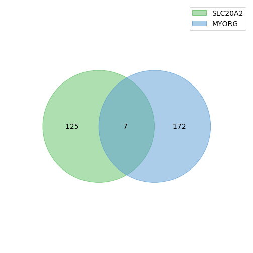

```
['hsa-miR-340-5p', 'hsa-miR-6878-5p', 'hsa-miR-6132', 'hsa-miR-548s', 'hsa-miR-7157-5p', 'hsa-miR-4310', 'hsa-miR-4469']
```

```python
show2Venn(miRSLC, miRMYO, 'SLC20A2', 'MYORG')
```

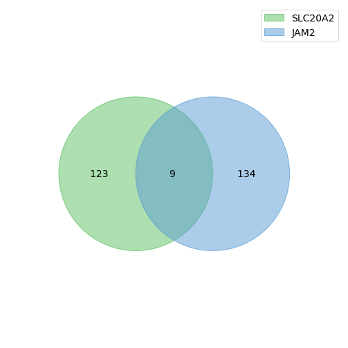

```
['hsa-miR-3613-3p', 'hsa-miR-6878-5p', 'hsa-miR-548ao-5p', 'hsa-miR-548ax', 'hsa-miR-338-5p', 'hsa-miR-548c-3p', 'hsa-miR-6844', 'hsa-miR-150-5p', 'hsa-miR-197-3p']
```

```python
show2Venn(miRSLC, miRJAM, 'SLC20A2', 'JAM2')
```

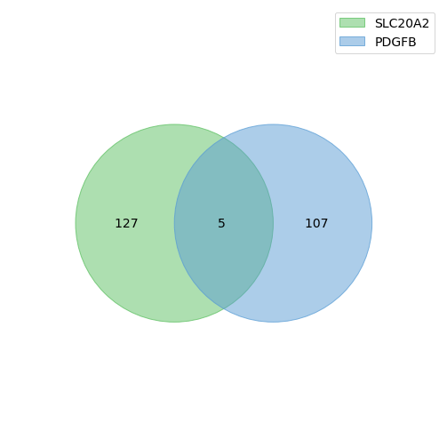

```
['hsa-miR-4441', 'hsa-miR-3202', 'hsa-miR-5194', 'hsa-miR-6738-5p', 'hsa-miR-767-5p']
```

```python
show2Venn(miRSLC, miRPDGFB, 'SLC20A2', 'PDGFB')
```

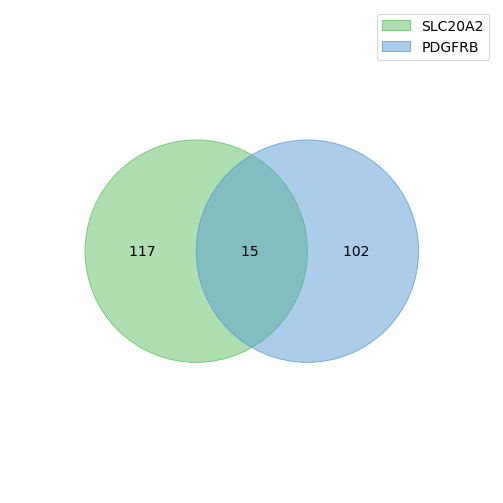

```
['hsa-miR-3184-5p', 'hsa-miR-423-5p', 'hsa-miR-9-5p', 'hsa-miR-889-3p', 'hsa-miR-12136', 'hsa-miR-4441', 'hsa-miR-6754-5p', 'hsa-miR-4270', 'hsa-miR-1263', 'hsa-miR-150-3p', 'hsa-miR-548n', 'hsa-miR-4672', 'hsa-miR-7157-5p', 'hsa-miR-4310', 'hsa-miR-2861']
```

```python
show2Venn(miRSLC, miRPDGFRB, 'SLC20A2', 'PDGFRB')
```

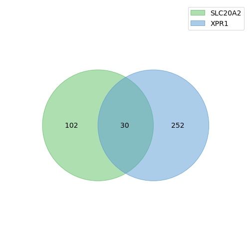

```
['hsa-miR-3613-3p', 'hsa-miR-16-5p', 'hsa-miR-15b-5p', 'hsa-miR-15a-5p', 'hsa-miR-195-5p', 'hsa-miR-5585-5p', 'hsa-miR-6838-5p', 'hsa-miR-497-5p', 'hsa-miR-424-5p', 'hsa-miR-6878-5p', 'hsa-miR-484', 'hsa-miR-3155a', 'hsa-miR-3155b', 'hsa-miR-12136', 'hsa-miR-513c-3p', 'hsa-miR-193a-3p', 'hsa-miR-193…
```

```python
show2Venn(miRSLC, miRXPR1, 'SLC20A2', 'XPR1')
```

```python
#3-Venn intersect
miRSlcMyoPdgfb = getIntersect(miRSlcMyo, miRPDGFB)
print(miRSlcMyoPdgfb)
miRSlcMyoPdgfrb = getIntersect(miRSlcMyo, miRPDGFRB)
print(miRSlcMyoPdgfrb)
miRSlcMyoXpr1 = getIntersect(miRSlcMyo, miRXPR1)
print(miRSlcMyoXpr1)
miRSlcMyoJam2 = getIntersect(miRSlcMyo, miRJAM)
print(miRSlcMyoJam2)

miRSlcPdgfbPdgfrb = getIntersect(miRSlcPdgfb, miRPDGFRB)
print(miRSlcPdgfbPdgfrb)
miRSlcPdgfbXpr1 = getIntersect(miRSlcPdgfb, miRXPR1)
print(miRSlcPdgfbXpr1)
miRSlcPdgfbJam2 = getIntersect(miRSlcPdgfb, miRJAM)
print(miRSlcPdgfbJam2)

miRSlcPdgfrbXpr1 = getIntersect(miRSlcPdgfrb, miRXPR1)
print(miRSlcPdgfrbXpr1)
miRSlcPdgfrbJam2 = getIntersect(miRSlcPdgfrb, miRJAM)
print(miRSlcPdgfrbJam2)

miRSlcXpr1Jam2 = getIntersect(miRSlcXpr1, miRJAM)
print(miRSlcXpr1Jam2)

miRMyoPdgfbPdgfrb = getIntersect(miRMyoPdgfb, miRPDGFRB)
print(miRMyoPdgfbPdgfrb)
miRMyoPdgfbXpr1 = getIntersect(miRMyoPdgfb, miRXPR1)
print(miRMyoPdgfbXpr1)
miRMyoPdgfbJam2 = getIntersect(miRMyoPdgfb, miRJAM)
print(miRMyoPdgfbJam2)

miRMyoPdgfrbXpr1 = getIntersect(miRMyoPdgfrb, miRXPR1)
print(miRMyoPdgfrbXpr1)
miRMyoPdgfrbJam2 = getIntersect(miRMyoPdgfrb, miRJAM)
print(miRMyoPdgfrbJam2)

miRMyoXpr1Jam2 = getIntersect(miRMyoXpr1, miRJAM)
print(miRMyoXpr1Jam2)

miRPdgfbPdgfrbXpr1 = getIntersect(miRPdgfbPdgfrb, miRXPR1)
print(miRPdgfbPdgfrbXpr1)
miRPdgfbPdgfrbJam2 = getIntersect(miRPdgfbPdgfrb, miRJAM)
print(miRPdgfbPdgfrbJam2)
miRPdgfbXpr1Jam2 = getIntersect(miRPdgfbXpr1, miRJAM)
print(miRPdgfbPdgfrbXpr1)

miRPdgfrbXpr1Jam2 = getIntersect(miRPdgfrbXpr1, miRJAM)
print(miRPdgfrbXpr1Jam2)
```

```
[]
['hsa-miR-7157-5p', 'hsa-miR-4310']
['hsa-miR-6878-5p']
['hsa-miR-6878-5p']
['hsa-miR-4441']
[]
[]
['hsa-miR-12136']
[]
['hsa-miR-3613-3p', 'hsa-miR-6878-5p', 'hsa-miR-548ao-5p', 'hsa-miR-548ax']
['hsa-miR-4692', 'hsa-miR-4728-5p', 'hsa-miR-6785-5p', 'hsa-miR-149-3p', 'hsa-miR-6883-5p', 'hsa-miR-6745']
['hsa-miR-4667-3p']
['hsa-miR-4728-5p', 'hsa-miR-6785-5p', 'hsa-miR-149-3p']
['hsa-miR-1207-3p']
['hsa-miR-10394-5p', 'hsa-miR-1205', 'hsa-miR-4728-5p', 'hsa-miR-6785-5p', 'hsa-miR-149-3p']
['hsa-miR-6878-5p']
[]
['hsa-miR-6785-5p', 'hsa-miR-4728-5p', 'hsa-miR-149-3p']
[]
['hsa-miR-30b-5p', 'hsa-miR-30c-5p', 'hsa-miR-30e-5p', 'hsa-miR-30d-5p', 'hsa-miR-30a-5p']
```

```python
targetsThree = []
allThreeVenn = [
    miRSlcMyoPdgfb, miRSlcMyoPdgfrb, miRSlcMyoXpr1, miRSlcMyoJam2,
    miRSlcPdgfbPdgfrb, miRSlcPdgfbXpr1, miRSlcPdgfbJam2, miRSlcPdgfrbXpr1,
    miRSlcPdgfrbJam2, miRSlcXpr1Jam2, miRMyoPdgfbPdgfrb, miRMyoPdgfbXpr1,
    miRMyoPdgfbJam2, miRMyoPdgfrbXpr1, miRMyoPdgfrbJam2, miRMyoXpr1Jam2,
    miRPdgfbPdgfrbXpr1, miRPdgfbPdgfrbJam2, miRPdgfbXpr1Jam2, miRPdgfrbXpr1Jam2
                ]

for lista in allThreeVenn:
    for miR in lista:
        if miR not in targetsThree:
            targetsThree.append(miR)
print(len(targetsThree))
print(targetsThree)
```

```
24
['hsa-miR-7157-5p', 'hsa-miR-4310', 'hsa-miR-6878-5p', 'hsa-miR-4441', 'hsa-miR-12136', 'hsa-miR-3613-3p', 'hsa-miR-548ao-5p', 'hsa-miR-548ax', 'hsa-miR-4692', 'hsa-miR-4728-5p', 'hsa-miR-6785-5p', 'hsa-miR-149-3p', 'hsa-miR-6883-5p', 'hsa-miR-6745', 'hsa-miR-4667-3p', 'hsa-miR-1207-3p', 'hsa-miR-10…
```

```python
#3-Venn Show
```

```python
#4-Venn intersect

miRSlcMyoPdgfbPdgfrb = getIntersect(miRSlcMyoPdgfb, miRPDGFRB)
print(miRSlcMyoPdgfbPdgfrb)
miRSlcMyoPdgfbXpr1 = getIntersect(miRSlcMyoPdgfb, miRXPR1)
print(miRSlcMyoPdgfbXpr1)
miRSlcMyoPdgfbJam2 = getIntersect(miRSlcMyoPdgfb, miRJAM)
print(miRSlcMyoPdgfbJam2)

miRSlcMyoPdgfrbXpr1 = getIntersect(miRSlcMyoPdgfrb, miRXPR1)
print(miRSlcMyoPdgfrbXpr1)
miRSlcMyoPdgfrbJam2 = getIntersect(miRSlcMyoPdgfrb, miRJAM)
print(miRSlcMyoPdgfrbJam2)

miRSlcMyoXpr1Jam2 = getIntersect(miRSlcMyoXpr1, miRJAM)
print(miRSlcMyoXpr1Jam2)

miRMyoPdgfbPdgfrbXpr1 = getIntersect(miRMyoPdgfbPdgfrb, miRXPR1)
print(miRMyoPdgfbPdgfrbXpr1)
miRMyoPdgfbPdgfrbJam2 = getIntersect(miRMyoPdgfbPdgfrb, miRJAM)
print(miRMyoPdgfbPdgfrbJam2)
miRMyoPdgfbXpr1Jam2 = getIntersect(miRMyoPdgfbXpr1, miRJAM)
print(miRMyoPdgfbXpr1Jam2)
miRMyoPdgfrbXpr1Jam2 = getIntersect(miRMyoPdgfrbXpr1, miRJAM)
print(miRMyoPdgfrbXpr1Jam2)

miRPdgfbPdgfrbXpr1Jam2 = getIntersect(miRPdgfbPdgfrbXpr1, miRJAM)
print(miRPdgfbPdgfrbXpr1Jam2)
```

```
[]
[]
[]
[]
[]
['hsa-miR-6878-5p']
[]
['hsa-miR-4728-5p', 'hsa-miR-6785-5p', 'hsa-miR-149-3p']
[]
[]
[]
```

```python
targetsFour = []
allFourVenn = [
    miRSlcMyoPdgfbPdgfrb, miRSlcMyoPdgfbXpr1, miRSlcMyoPdgfbJam2,
    miRSlcMyoPdgfrbXpr1, miRSlcMyoPdgfrbJam2, miRSlcMyoXpr1Jam2,
    miRMyoPdgfbPdgfrbXpr1, miRMyoPdgfbPdgfrbJam2, miRMyoPdgfbXpr1Jam2,
    miRMyoPdgfrbXpr1Jam2, miRPdgfbPdgfrbXpr1Jam2
]

for lista in allFourVenn:
    for miR in lista:
        if miR not in targetsFour:
            targetsFour.append(miR)
print(len(targetsFour))
print(targetsFour)
```

```
4
['hsa-miR-6878-5p', 'hsa-miR-4728-5p', 'hsa-miR-6785-5p', 'hsa-miR-149-3p']
```

```python
#4-Venn Show
```

```python
#5-Venn Intersect

miRSlcMyoPdgfbPdgfrbXpr1 = getIntersect(miRSlcMyoPdgfbPdgfrb, miRXPR1)
print(miRSlcMyoPdgfbPdgfrbXpr1)
miRSlcMyoPdgfbPdgfrbJam2 = getIntersect(miRSlcMyoPdgfbPdgfrb, miRJAM)
print(miRSlcMyoPdgfbPdgfrbJam2)

miRMyoPdgfbPdgfrbXpr1Jam2 = getIntersect(miRMyoPdgfbPdgfrbXpr1, miRJAM)
print(miRMyoPdgfbPdgfrbXpr1Jam2)
```

```
[]
[]
[]
```

```python
#5-Venn Show
```

```python
#6-Venn Intersect
miRSlcMyoPdgfbPdgfrbXpr1Jam2 = getIntersect(miRSlcMyoPdgfbPdgfrbXpr1, miRJAM)
print(miRSlcMyoPdgfbPdgfrbXpr1Jam2)
```

```
[]
```

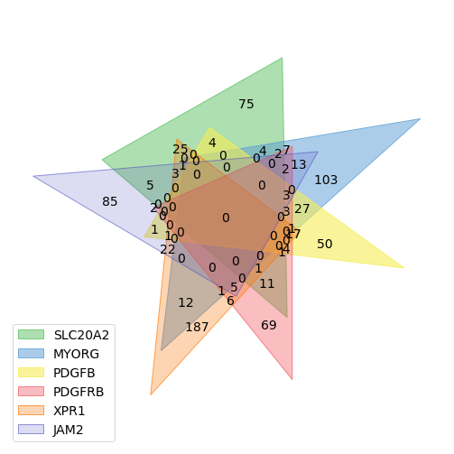

```python
#6-Venn
%matplotlib inline
labels = venn.get_labels([set(miRSLC), set(miRMYO), set(miRPDGFB), set(miRPDGFRB), set(miRXPR1), set(miRJAM)], fill=['number']
                        )
fig, ax = venn.venn6(labels, names=['SLC20A2', 'MYORG', 'PDGFB', 'PDGFRB', 'XPR1', 'JAM2'])
plt.figure(figsize=(30,20))
plt.savefig('miRVenn.png', bbox_inches='tight')
plt.show()
```

```python
for miR in targetsFour:
    if miR in slc20a2['miRNA Name'].values:
        print('Target Score between ' + str(miR) + ' and SLC20A2: ' + str(int(slc20a2[slc20a2['miRNA Name'].str.contains(miR)]['Target Score'].values)))
    if miR in xpr1['miRNA Name'].values:
        print('Target Score between ' + str(miR) + ' and XPR1: ' + str(int(xpr1[xpr1['miRNA Name'].str.contains(miR)]['Target Score'].values)))
    if miR in myorg['miRNA Name'].values:
        print('Target Score between ' + str(miR) + ' and MYORG: ' + str(int(myorg[myorg['miRNA Name'].str.contains(miR)]['Target Score'].values)))
    if miR in pdgfb['miRNA Name'].values:
        print('Target Score between ' + str(miR) + ' and PDGFB: ' + str(int(pdgfb[pdgfb['miRNA Name'].str.contains(miR)]['Target Score'].values)))
    if miR in pdgfrb['miRNA Name'].values:
        print('Target Score between ' + str(miR) + ' and PDGFRB: ' + str(int(pdgfrb[pdgfrb['miRNA Name'].str.contains(miR)]['Target Score'].values)))
    if miR in jam2['miRNA Name'].values:
        print('Target Score between ' + str(miR) + ' and JAM2: ' + str(int(jam2[jam2['miRNA Name'].str.contains(miR)]['Target Score'].values)))
```

```
Target Score between hsa-miR-6878-5p and SLC20A2: 88
Target Score between hsa-miR-6878-5p and XPR1: 94
Target Score between hsa-miR-6878-5p and MYORG: 51
Target Score between hsa-miR-6878-5p and JAM2: 54
Target Score between hsa-miR-4728-5p and MYORG: 60
Target Score between hsa-miR-4728-5p and PDGFB: 60
Target Score between hsa-miR-4728-5p and PDGFRB: 61
Target Score between hsa-miR-4728-5p and JAM2: 62
Target Score between hsa-miR-6785-5p and MYORG: 60
Target Score between hsa-miR-6785-5p and PDGFB: 60
Target Score between hsa-miR-6785-5p and PDGFRB: 61
Target Score between hsa-miR-6785-5p and JAM2: 54
Target Score between hsa-miR-149-3p and MYORG: 56
Target Score between hsa-miR-149-3p and PDGFB: 55
Target Score between hsa-miR-149-3p and PDGFRB: 61
Target Score between hsa-miR-149-3p and JAM2: 55
```

### Figure: Molecular Network of microRNAs and PFBC-genes

[figure not shown]

Figure Legend:  
A representation of a putative molecular network binding all PFBC-genes by their interaction (regulation) with microRNAs. miR4728, miR6785, and miR149 links PFBC genes by targeting simultaneously PDGFB, PDGFRB, MYORG and JAM2, while miR6878 does the same to SLC20A2, MYORG, JAM2 and XPR1.

#### Discussion

We have found microRNAs that target more than one PFBC-causing gene simultaneously. Of a total of 753 microRNAs, 184 target at least two PFBC-causing genes at the same time, 24 target three genes simultaneously, and 4 target four of the six genes.  
Although no microRNA targets all six genes, we have found that miR4728, miR6785, miR149 all target simultaneously PDGFB, PDGFRB, MYORG, JAM2 genes. Little is known about these microRNAs, and currently they are not linked to any specific pathway or disease. miR4728 and miR149 were reported in breast and cervical cancer studies (Lui, Pourmand, Patterson and Fire 2007; Persson et al, 2011), while no specific function or role was described for these molecules. miR6878 targets SLC20A2, XPR1, JAM2 and MYORG simultaneously, though no functional study was reported for this microRNA. Even though no specific role is confirmed for these microRNAs, they link the PFBC-causing genes together through potentially shared regulatory processes,.  
This study identifies potential microRNAs that may participate in the progression of PFBC through the regulation of several PFBC-causing genes at the same time. Experimental in vitro studies are necessary to confirm the microRNAs regulatory process of PFBC genes, and further in vivo studies may be needed to confirm their role in the pathological phenotype of the disease.

#### Conclusion

This project successfully identified microRNAs that target simultaneously more than two PFBC-causing genes. miR4728, miR6785, miR149 and miR6878 through their regulatory potential of PFBC-causing genes, are important candidates for the development of PFBC phenotypes. Their specific function in regulating such genes is still unknown. Experimental in vitro and in vivo analysis are necessary to confirm these associations and the understand their function on PFBC.